# Chapter 5: Dimensionality reduction techniques

Lets begin the Chapter 5 by loading the data.

This weeks data contains a large variety of countries. We look for example their life expectancy, GNI and education expectancy.

```r
human <- read.table("http://s3.amazonaws.com/assets.datacamp.com/production/course_2218/datasets/human2.txt", header = T, sep=",")

dim(human)
```

```
## [1] 155   8
```

```r
str(human)
```

```
## 'data.frame':    155 obs. of  8 variables:
##  $ Edu2.FM  : num  1.007 0.997 0.983 0.989 0.969 ...
##  $ Labo.FM  : num  0.891 0.819 0.825 0.884 0.829 ...
##  $ Edu.Exp  : num  17.5 20.2 15.8 18.7 17.9 16.5 18.6 16.5 15.9 19.2 ...
##  $ Life.Exp : num  81.6 82.4 83 80.2 81.6 80.9 80.9 79.1 82 81.8 ...
##  $ GNI      : int  64992 42261 56431 44025 45435 43919 39568 52947 42155 32689 ...
##  $ Mat.Mor  : int  4 6 6 5 6 7 9 28 11 8 ...
##  $ Ado.Birth: num  7.8 12.1 1.9 5.1 6.2 3.8 8.2 31 14.5 25.3 ...
##  $ Parli.F  : num  39.6 30.5 28.5 38 36.9 36.9 19.9 19.4 28.2 31.4 ...
```

We have 155 observations (countries) and 8 different variables. Next we look at the graphical overview of the data and try to see correlations between the variables.

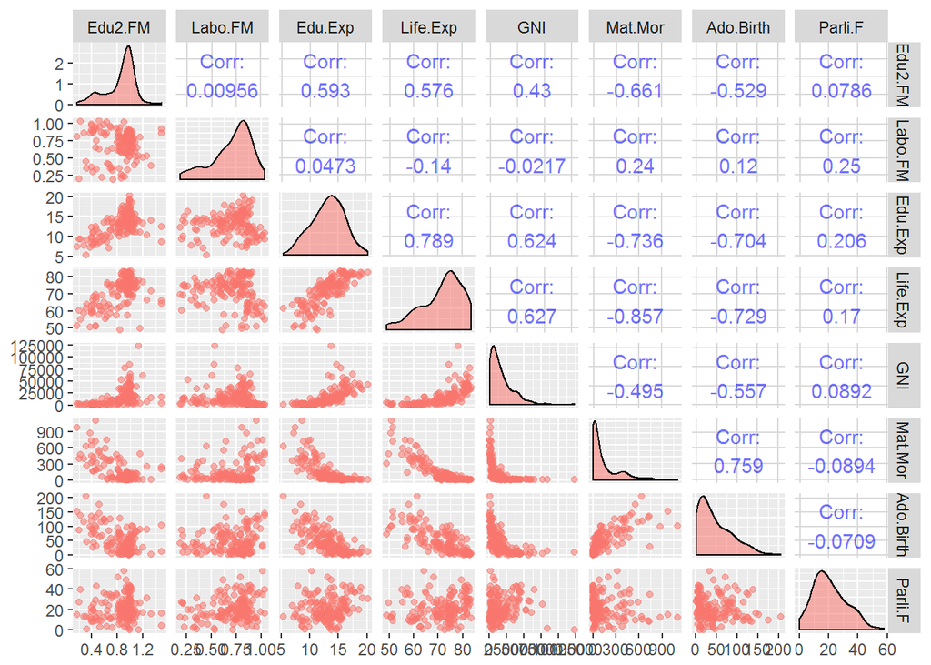

```r
p <- ggpairs(human, mapping = aes(col="blue", alpha=0.3), lower = list(combo = wrap("facethist", bins = 20)))

p
```

There is a lot of significant correlations between the variables. For example Mat.mor - Ado.birth has 0.759 correlation.

```r
summary(human)
```

```
##     Edu2.FM          Labo.FM          Edu.Exp         Life.Exp
##  Min.   :0.1717   Min.   :0.1857   Min.   : 5.40   Min.   :49.00
##  1st Qu.:0.7264   1st Qu.:0.5984   1st Qu.:11.25   1st Qu.:66.30
##  Median :0.9375   Median :0.7535   Median :13.50   Median :74.20
##  Mean   :0.8529   Mean   :0.7074   Mean   :13.18   Mean   :71.65
##  3rd Qu.:0.9968   3rd Qu.:0.8535   3rd Qu.:15.20   3rd Qu.:77.25
##  Max.   :1.4967   Max.   :1.0380   Max.   :20.20   Max.   :83.50
##       GNI            Mat.Mor         Ado.Birth         Parli.F
##  Min.   :   581   Min.   :   1.0   Min.   :  0.60   Min.   : 0.00
##  1st Qu.:  4198   1st Qu.:  11.5   1st Qu.: 12.65   1st Qu.:12.40
##  Median : 12040   Median :  49.0   Median : 33.60   Median :19.30
##  Mean   : 17628   Mean   : 149.1   Mean   : 47.16   Mean   :20.91
##  3rd Qu.: 24512   3rd Qu.: 190.0   3rd Qu.: 71.95   3rd Qu.:27.95
##  Max.   :123124   Max.   :1100.0   Max.   :204.80   Max.   :57.50
```

Next I chose a couple of interesting variables and tried to explain them with GNI also known as Gross National Income ($). I chose two variables: Life Expectancy (in years) and Education Expectancy (in years).

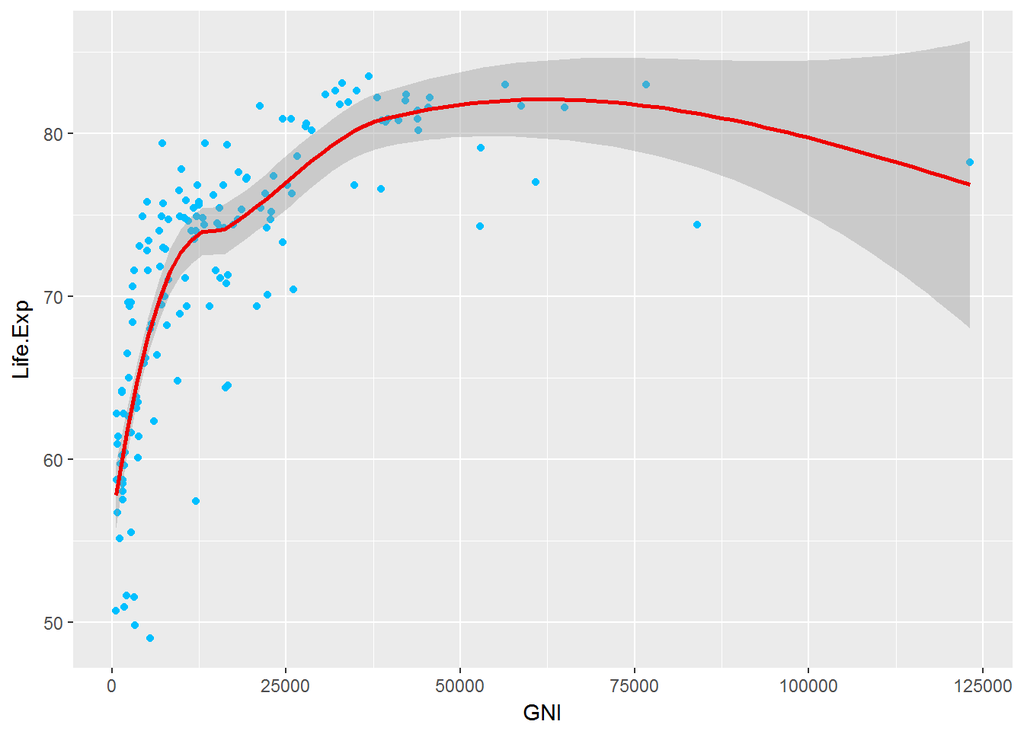

```r
p2 <- ggplot(human, aes(x=GNI, y= Life.Exp)) + geom_point(col="deepskyblue1") + geom_smooth( col = "red2")

p2
```

```r
model5 <- lm(Life.Exp ~ GNI, human)
summary(model5)
```

```
##
## Call:
## lm(formula = Life.Exp ~ GNI, data = human)
##
## Residuals:
##     Min      1Q  Median      3Q     Max
## -23.158  -3.759   2.058   4.801  10.654
##
## Coefficients:
##              Estimate Std. Error t value Pr(>|t|)
## (Intercept) 6.669e+01  7.230e-01  92.236   <2e-16 ***
## GNI         2.816e-04  2.831e-05   9.947   <2e-16 ***
## ---
## Signif. codes:  0 '***' 0.001 '**' 0.01 '*' 0.05 '.' 0.1 ' ' 1
##
## Residual standard error: 6.514 on 153 degrees of freedom
## Multiple R-squared:  0.3927, Adjusted R-squared:  0.3887
## F-statistic: 98.94 on 1 and 153 DF,  p-value: < 2.2e-16
```

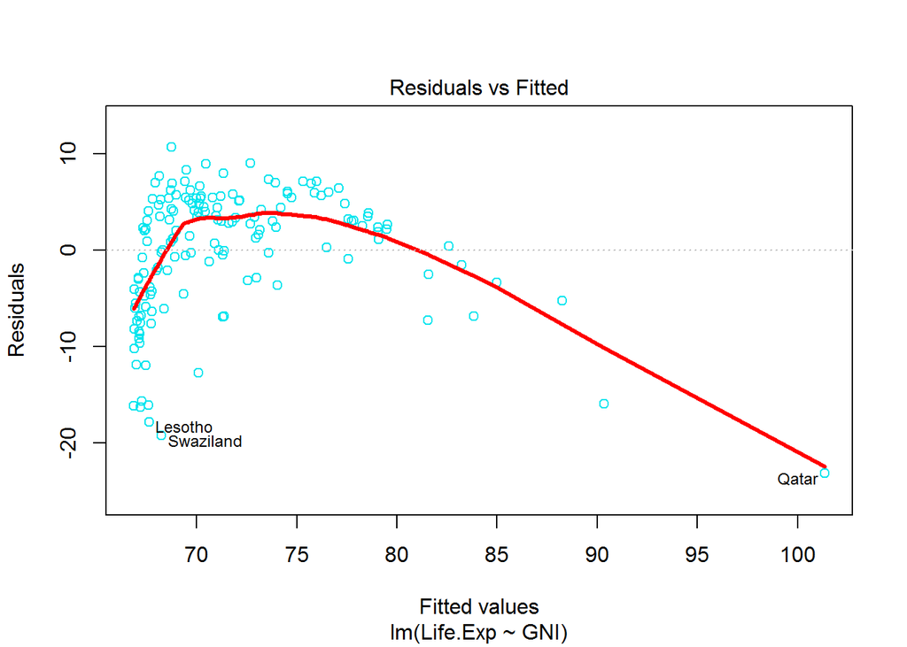

```r
plot(model5,  which=c(1), col = "turquoise2",  lwd = 3)
```

As we see there are quite a few outliers such as Qatar that make the model hard to fit.

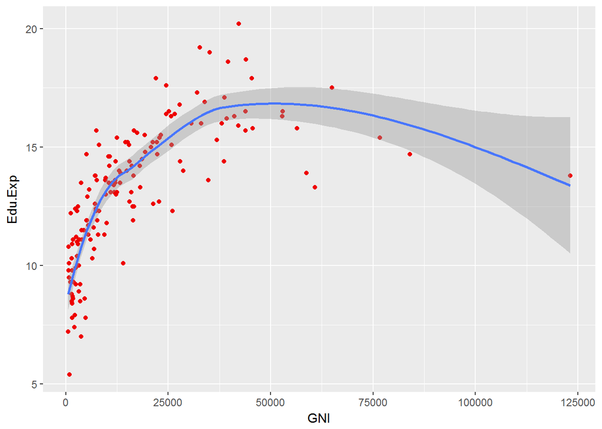

```r
p3 <- ggplot(human, aes(x=GNI, y= Edu.Exp)) + geom_point(col="red2") + geom_smooth(col = "royalblue1")

p3
```

```r
model6 <- lm(Edu.Exp ~ GNI, human)
summary(model6)
```

```
##
## Call:
## lm(formula = Edu.Exp ~ GNI, data = human)
##
## Residuals:
##     Min      1Q  Median      3Q     Max
## -9.4643 -1.0889  0.2784  1.4838  4.6683
##
## Coefficients:
##              Estimate Std. Error t value Pr(>|t|)
## (Intercept) 1.149e+01  2.471e-01  46.509   <2e-16 ***
## GNI         9.563e-05  9.673e-06   9.886   <2e-16 ***
## ---
## Signif. codes:  0 '***' 0.001 '**' 0.01 '*' 0.05 '.' 0.1 ' ' 1
##
## Residual standard error: 2.226 on 153 degrees of freedom
## Multiple R-squared:  0.3898, Adjusted R-squared:  0.3858
## F-statistic: 97.74 on 1 and 153 DF,  p-value: < 2.2e-16
```

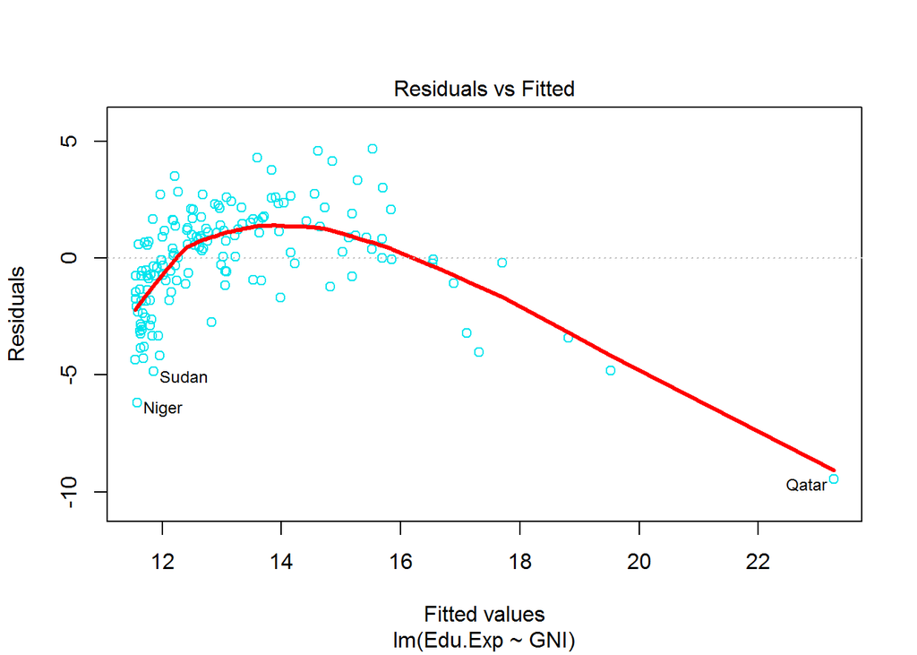

```r
plot(model6,  which=c(1), col = "turquoise2",  lwd = 3)
```

This model also suffers a bit as there are those large outliers such as Niger and Qatar.

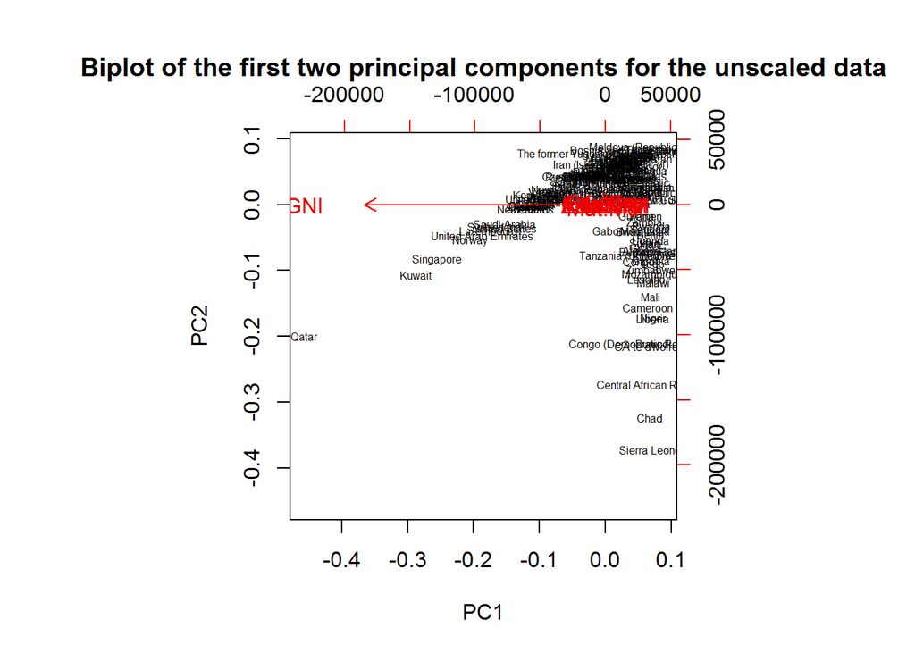

```r
# perform principal component analysis (with the SVD method)
pca_human <- prcomp(human)

# draw a biplot of the principal component representation and the original variables
biplot(pca_human, choices = 1:2, cex = c(0.5, 1), col = c("black", "red2"), main="Biplot of the first two principal components for the unscaled data")
```

The picture doesn’t look very good as we have not standardised the data. A lot of the observations are in the same spot and there seems to be very little correlation. Lets standardise the data and see how the situation changes.

```r
human_std <- scale(human)

pca_human11 <- prcomp(human_std)

summary(pca_human11)
```

```
## Importance of components:
##                           PC1    PC2     PC3     PC4     PC5     PC6
## Standard deviation     2.0708 1.1397 0.87505 0.77886 0.66196 0.53631
## Proportion of Variance 0.5361 0.1624 0.09571 0.07583 0.05477 0.03595
## Cumulative Proportion  0.5361 0.6984 0.79413 0.86996 0.92473 0.96069
##                            PC7     PC8
## Standard deviation     0.45900 0.32224
## Proportion of Variance 0.02634 0.01298
## Cumulative Proportion  0.98702 1.00000
```

The data is now standardised and we can draw a new biplot of the first two principal components.

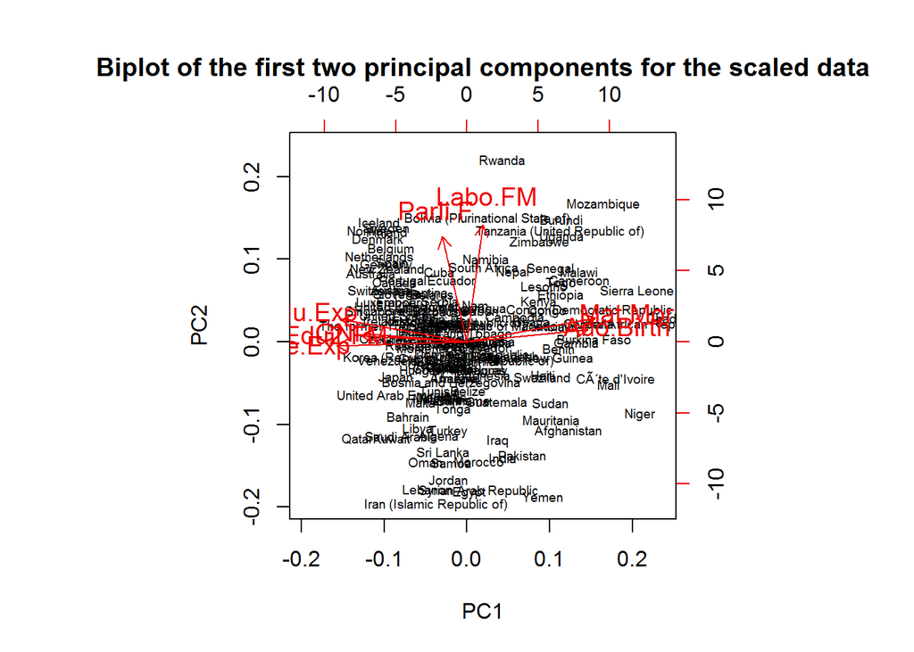

```r
biplot(pca_human11, choices = 1:2, cex = c(0.6, 1.2), col = c("black", "red2"),main="Biplot of the first two principal components for the scaled data")
```

Next we go the #part 2 and start it by loading the Tea dataset from Factominer package. It includes 300 observations about how people drink their tea and different habits that are part of the tea drinking.

```r
data("tea")
dim(tea)
```

```
## [1] 300  36
```

```r
str(tea)
```

```
## 'data.frame':    300 obs. of  36 variables:
##  $ breakfast       : Factor w/ 2 levels "breakfast","Not.breakfast": 1 1 2 2 1 2 1 2 1 1 ...
##  $ tea.time        : Factor w/ 2 levels "Not.tea time",..: 1 1 2 1 1 1 2 2 2 1 ...
##  $ evening         : Factor w/ 2 levels "evening","Not.evening": 2 2 1 2 1 2 2 1 2 1 ...
##  $ lunch           : Factor w/ 2 levels "lunch","Not.lunch": 2 2 2 2 2 2 2 2 2 2 ...
##  $ dinner          : Factor w/ 2 levels "dinner","Not.dinner": 2 2 1 1 2 1 2 2 2 2 ...
##  $ always          : Factor w/ 2 levels "always","Not.always": 2 2 2 2 1 2 2 2 2 2 ...
##  $ home            : Factor w/ 2 levels "home","Not.home": 1 1 1 1 1 1 1 1 1 1 ...
##  $ work            : Factor w/ 2 levels "Not.work","work": 1 1 2 1 1 1 1 1 1 1 ...
##  $ tearoom         : Factor w/ 2 levels "Not.tearoom",..: 1 1 1 1 1 1 1 1 1 2 ...
##  $ friends         : Factor w/ 2 levels "friends","Not.friends": 2 2 1 2 2 2 1 2 2 2 ...
##  $ resto           : Factor w/ 2 levels "Not.resto","resto": 1 1 2 1 1 1 1 1 1 1 ...
##  $ pub             : Factor w/ 2 levels "Not.pub","pub": 1 1 1 1 1 1 1 1 1 1 ...
##  $ Tea             : Factor w/ 3 levels "black","Earl Grey",..: 1 1 2 2 2 2 2 1 2 1 ...
##  $ How             : Factor w/ 4 levels "alone","lemon",..: 1 3 1 1 1 1 1 3 3 1 ...
```

[output cut: 22 more lines]

I decided to drop out some variables as there was 36 of them. It was quite impossible to plot and make a grapical overview with a such variety of different variables.

```r
keep <- c("friends", "Tea", "resto", "age_Q", "frequency")

teatimes <- dplyr::select(tea, one_of(keep))

str(teatimes)
```

```
## 'data.frame':    300 obs. of  5 variables:
##  $ friends  : Factor w/ 2 levels "friends","Not.friends": 2 2 1 2 2 2 1 2 2 2 ...
##  $ Tea      : Factor w/ 3 levels "black","Earl Grey",..: 1 1 2 2 2 2 2 1 2 1 ...
##  $ resto    : Factor w/ 2 levels "Not.resto","resto": 1 1 2 1 1 1 1 1 1 1 ...
##  $ age_Q    : Factor w/ 5 levels "15-24","25-34",..: 3 4 4 1 4 1 3 3 3 3 ...
##  $ frequency: Factor w/ 4 levels "1/day","1 to 2/week",..: 1 1 3 1 3 1 4 2 3 3 ...
```

These are the variables that I decided to keep. Next I drew a multiplot of them where we can see better how they look.

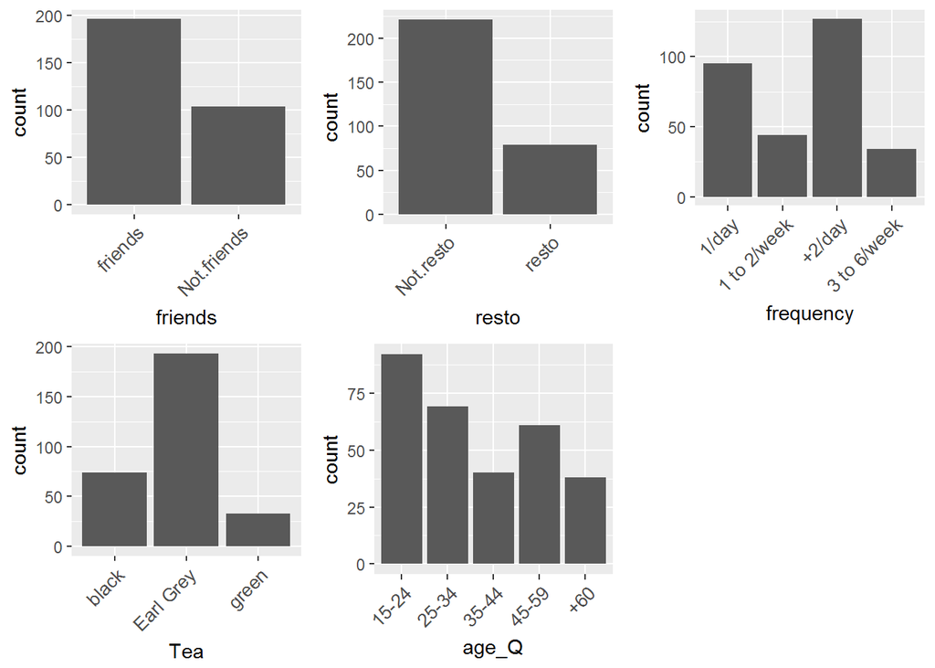

```r
g1 <- ggplot(teatimes, aes(friends)) + geom_bar() + theme_grey() + theme(axis.text.x = element_text(angle = 45, hjust = 1, size = 10))
g2 <- ggplot(teatimes, aes(Tea)) + geom_bar()+ theme_grey() +
  theme(axis.text.x = element_text(angle = 45, hjust = 1, size = 10))
g3 <- ggplot(teatimes, aes(resto)) + geom_bar() + theme_grey() + theme(axis.text.x = element_text(angle = 45, hjust = 1, size = 10))
g4 <- ggplot(teatimes, aes(age_Q)) + geom_bar()+ theme_grey() + theme(axis.text.x = element_text(angle = 45, hjust = 1, size = 10))
g5 <- ggplot(teatimes, aes(frequency)) + geom_bar()+ theme_grey() + theme(axis.text.x = element_text(angle = 45, hjust = 1, size = 10))

multiplot(g1, g2, g3, g4, g5, cols=3)
```

Now we do a MCA also known as Multiple Correspondence Analysis. This means that we represent the data in a low-dimensional Euclidean space. It is a counterpart of principal component analysis that we did above.

```r
mca <- MCA(X = teatimes, graph=F)

summary(mca)
```

```
##
## Call:
## MCA(X = teatimes, graph = F)
##
##
## Eigenvalues
##                        Dim.1   Dim.2   Dim.3   Dim.4   Dim.5   Dim.6
## Variance               0.298   0.270   0.235   0.217   0.210   0.195
## % of var.             13.547  12.257  10.703   9.861   9.545   8.847
## Cumulative % of var.  13.547  25.804  36.508  46.368  55.913  64.760
##                        Dim.7   Dim.8   Dim.9  Dim.10  Dim.11
## Variance               0.187   0.175   0.161   0.131   0.122
## % of var.              8.511   7.949   7.313   5.933   5.533
## Cumulative % of var.  73.271  81.221  88.534  94.467 100.000
##
## Individuals (the 10 first)
##                Dim.1    ctr   cos2    Dim.2    ctr   cos2    Dim.3    ctr
## 1           |  0.875  0.856  0.274 |  0.254  0.080  0.023 | -0.006  0.000
## 2           |  1.003  1.126  0.443 | -0.075  0.007  0.003 | -0.145  0.030
## 3           | -0.368  0.151  0.074 |  0.427  0.225  0.099 | -0.392  0.217
## 4           |  0.041  0.002  0.001 | -0.727  0.654  0.367 |  0.050  0.004
## 5           |  0.421  0.198  0.110 | -0.185  0.042  0.021 |  0.041  0.002
## 6           |  0.041  0.002  0.001 | -0.727  0.654  0.367 |  0.050  0.004
## 7           | -0.160  0.029  0.008 |  0.350  0.152  0.039 |  0.266  0.100
## 8           |  0.578  0.374  0.095 |  0.375  0.174  0.040 |  0.731  0.756
## 9           |  0.293  0.096  0.040 |  0.145  0.026  0.010 |  0.180  0.046
## 10          |  0.727  0.590  0.201 |  0.675  0.564  0.173 |  0.323  0.147
##               cos2
## 1            0.000 |
## 2            0.009 |
## 3            0.084 |
## 4            0.002 |
## 5            0.001 |
## 6            0.002 |
## 7            0.022 |
## 8            0.152 |
## 9            0.015 |
## 10           0.040 |
##
## Categories (the 10 first)
```

[output cut: 15 more lines]

```
## Earl Grey    -5.891 |  -0.117   0.748   0.025  -2.717 |
## green        -6.292 |   0.172   0.278   0.004   1.048 |
## Not.resto    -9.029 |   0.321   6.453   0.289   9.288 |
## resto         9.029 |  -0.898  18.053   0.289  -9.288 |
## 15-24        -4.741 |   0.723  13.606   0.231   8.312 |
## 25-34        -3.528 |  -1.211  28.641   0.438 -11.443 |
## 35-44         5.152 |   0.241   0.659   0.009   1.636 |
##
## Categorical variables (eta2)
##               Dim.1 Dim.2 Dim.3
## friends     | 0.402 0.037 0.006 |
## Tea         | 0.484 0.470 0.025 |
## resto       | 0.131 0.273 0.289 |
## age_Q       | 0.403 0.298 0.523 |
## frequency   | 0.071 0.271 0.335 |
```

We see the interesting values in v-test where the test-value is 1.96 that we compare against. A lot of times the v-test value is greater than |1.96| which means that a lot them are significant.

The last thing to do is to look at the grapical view of the MCA.

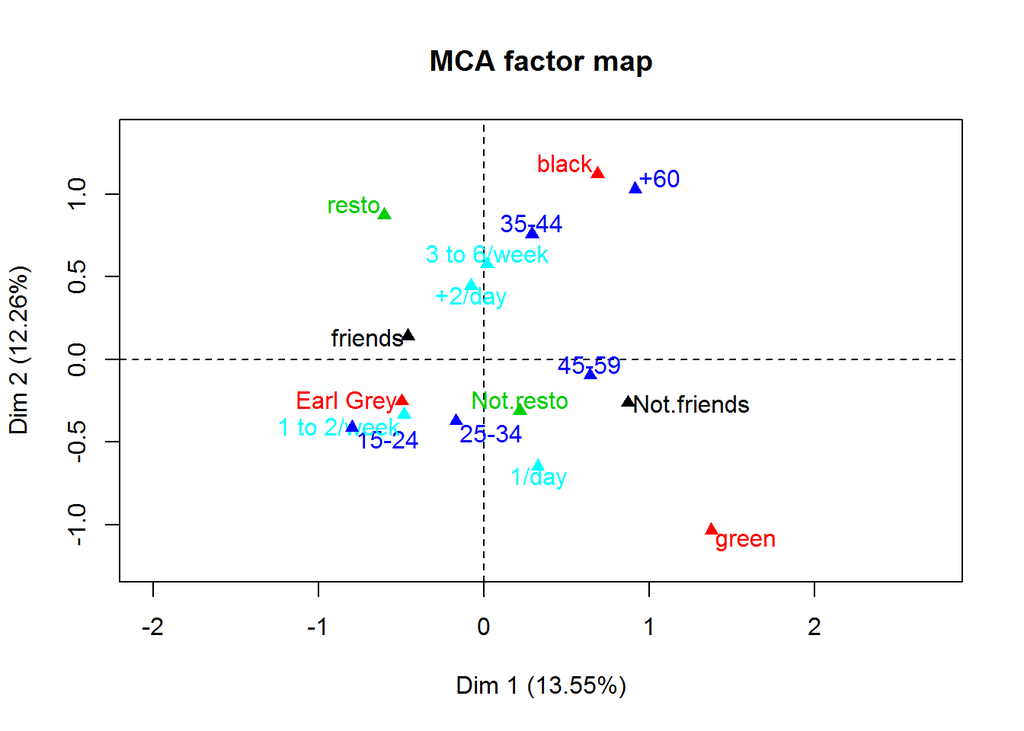

```r
plot(mca, invisible=c("ind"), habillage = "quali")
```

We see that the first two dimensions hold the most variance. Dim 1 has 13.55% and Dim 2 has 12.26%. The biggest outliers are green and black as we saw before that the most people in this dataset drink Earl Grey tea. From this we also see that the old people (+60) prefer black tea to others.